# NebideNet Statistics

Matt Edgar

2021-03-05

## Preliminary Information

Here is where I will put notes and code intended to make sure the rest of this document functions properly.

```r
getwd()
```

```
## [1] "C:/Users/matth/OneDrive/Documents/Coding/NebideNet"
```

## Randomly Generated Models

One important part of generating models is testing their biases. Here is a set of data based on models generated to work with the Community Crime Dataset.

```r
data.gss <- read.csv("gaussStats.csv", header = TRUE)
head(data.gss)
```

```
##         PgS      PgNS        Parity     Ratio Median  MeanScore DeviationScore
## 1 0.9917695 0.9902857  0.0014838330 1.0014984      1 0.99039420     0.08479617
## 2 0.3909465 0.1531429  0.2378036449 2.5528223      0 0.18590153     0.35802507
## 3 0.8683128 0.6657143  0.2025984715 1.3043325      1 0.68715869     0.41579823
## 4 0.7160494 0.7874286 -0.0713791887 0.9093515      1 0.77586454     0.37550417
## 5 0.2098765 0.0320000  0.1778765432 6.5586420      0 0.05736111     0.20872442
## 6 1.0000000 0.9994286  0.0005714286 1.0005718      1 0.99906390     0.02516801
```

```r
data.uni <- read.csv("uniformStats.csv", header = TRUE)
head(data.uni)
```

```
##          PgS        PgNS       Parity      Ratio Median   MeanScore
## 1 0.01646091 0.034285714 -0.017824809  0.4801097      0 0.036264947
## 2 0.00000000 0.002857143 -0.002857143 -1.0000000      0 0.003006201
## 3 0.94238683 0.994857143 -0.052470312  0.9472584      1 0.984951839
## 4 0.29218107 0.084571429  0.207609641  3.4548437      0 0.115741016
## 5 0.07818930 0.061142857  0.017046443  1.2787970      0 0.071433518
## 6 0.00000000 0.000000000  0.000000000 -1.0000000      0 0.000000000
##   DeviationScore
## 1     0.15455640
## 2     0.04565664
## 3     0.09353085
## 4     0.27570009
## 5     0.20937610
## 6     0.00000000
```

```r
data.rni <- read.csv("reducedUniformStats.csv", header = TRUE)
head(data.rni)
```

```
##           PgS         PgNS       Parity      Ratio   Median    MeanScore
## 1 0.000000000 0.0000000000  0.000000000 -1.0000000 0.000000 0.0000000000
## 2 0.201646091 0.4760000000 -0.274353909  0.4236262 0.392091 0.4530769277
## 3 0.000000000 0.0057142857 -0.005714286 -1.0000000 0.000000 0.0128284193
## 4 0.000000000 0.0000000000  0.000000000 -1.0000000 0.000000 0.0004035041
## 5 0.000000000 0.0222857143 -0.022285714 -1.0000000 0.000000 0.0204752931
## 6 0.004115226 0.0005714286  0.003543798  7.2016461 0.000000 0.0053396340
##   DeviationScore
## 1    0.000000000
## 2    0.404952136
## 3    0.071650434
## 4    0.008471585
## 5    0.107143113
## 6    0.041605658
```

## Graphs with No Context

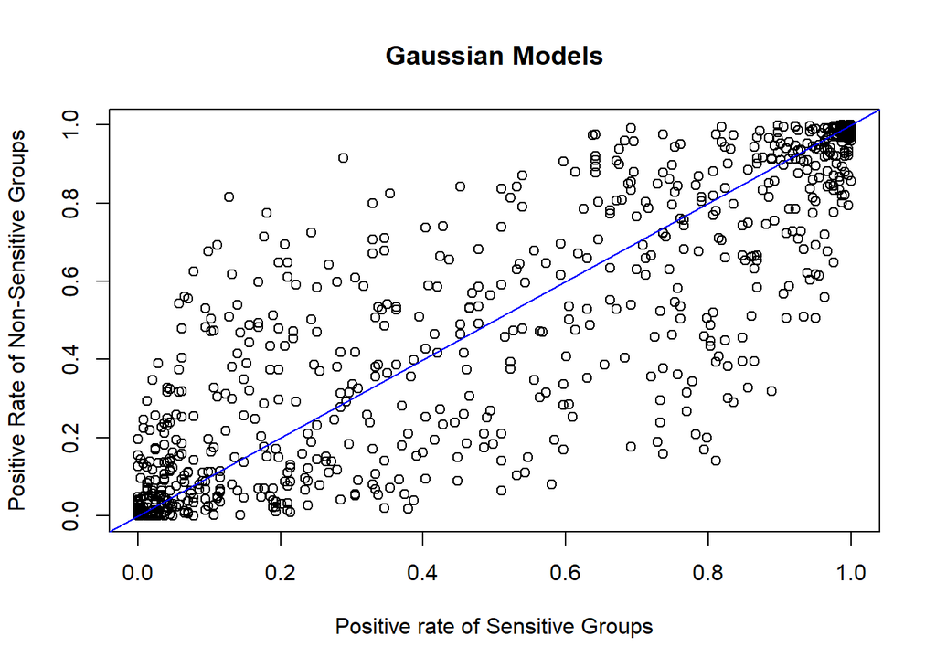

```r
with(data.gss, plot(PgNS~PgS, ylab = "Positive Rate of Non-Sensitive Groups", xlab = "Positive rate of Sensitive Groups", main = "Gaussian Models"))
abline(0, 1, col = "Blue")
```

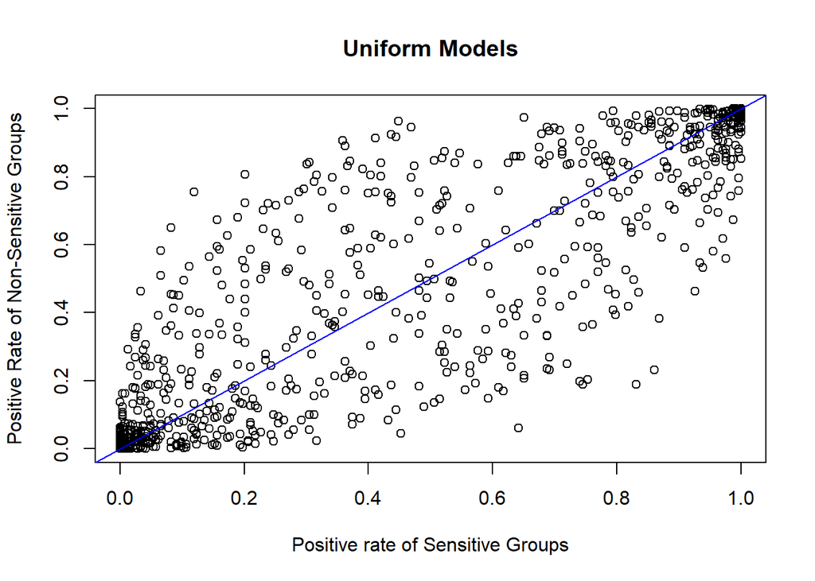

```r
with(data.uni, plot(PgNS~PgS, ylab = "Positive Rate of Non-Sensitive Groups", xlab = "Positive rate of Sensitive Groups", main = "Uniform Models"))
abline(0, 1, col = "Blue")
```

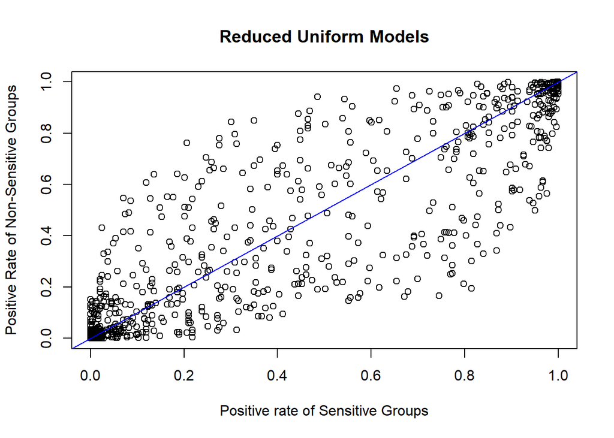

```r
with(data.rni, plot(PgNS~PgS, ylab = "Positive Rate of Non-Sensitive Groups", xlab = "Positive rate of Sensitive Groups", main = "Reduced Uniform Models"))
abline(0, 1, col = "Blue")
```

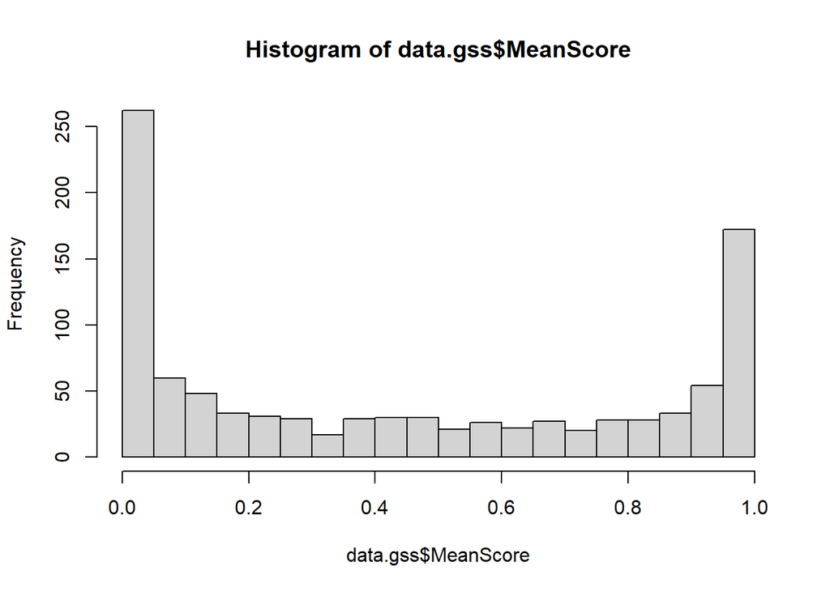

```r
hist(data.gss$MeanScore, breaks = 20)
```

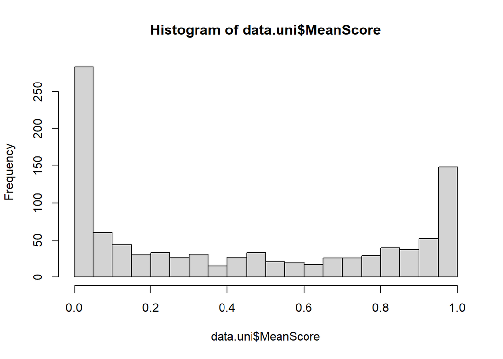

```r
hist(data.uni$MeanScore, breaks = 20)
```

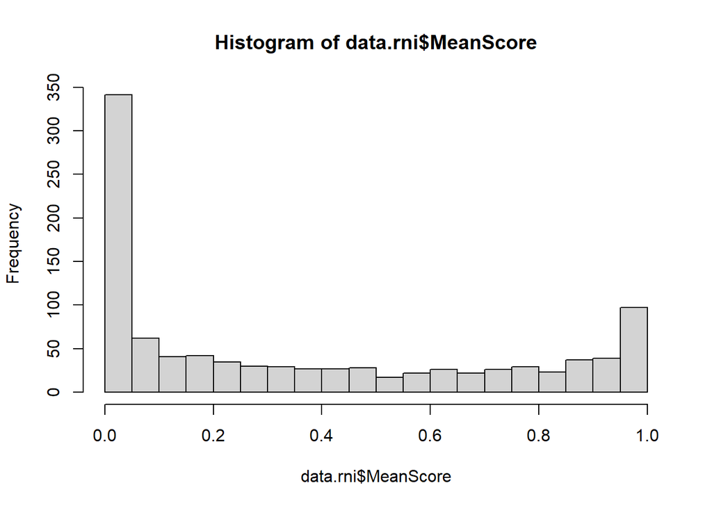

```r
hist(data.rni$MeanScore, breaks = 20)
```

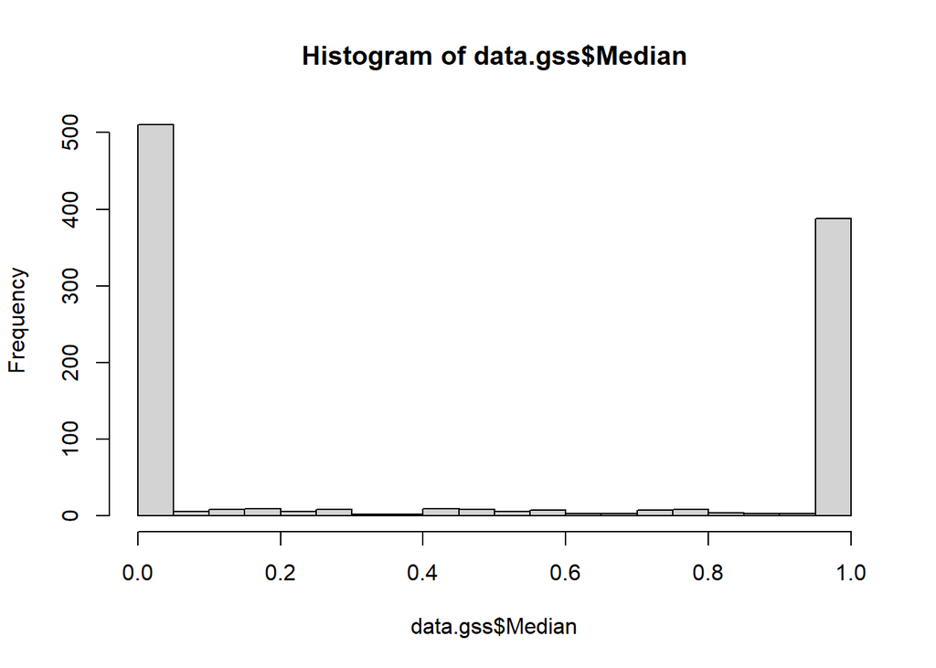

```r
hist(data.gss$Median, breaks = 20)
```

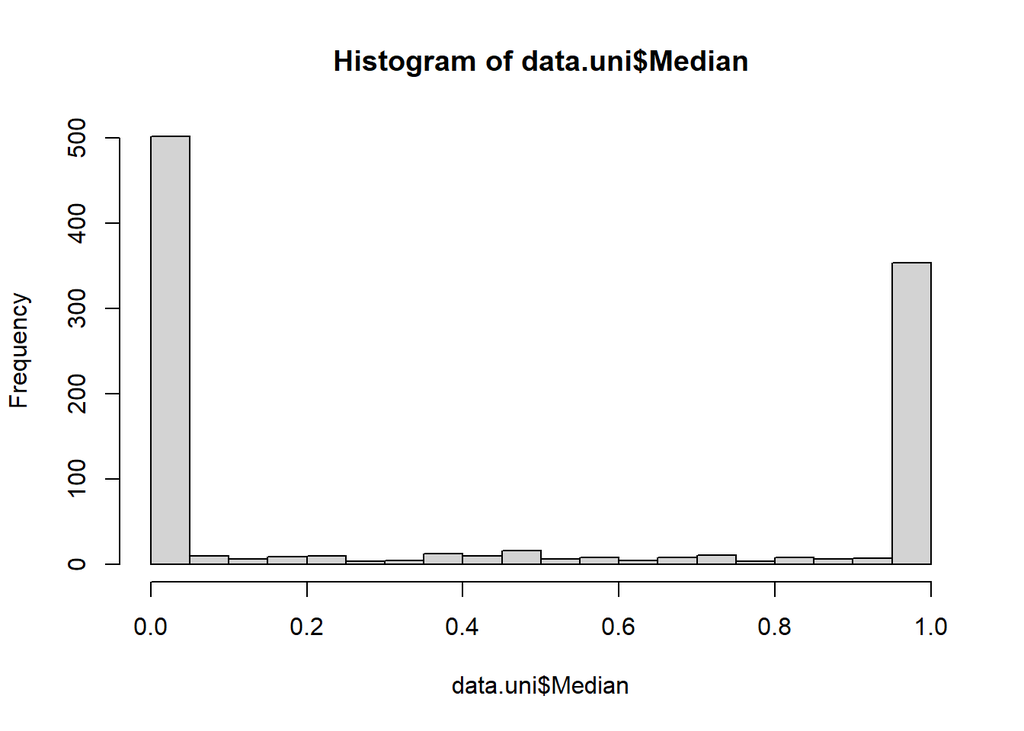

```r
hist(data.uni$Median, breaks = 20)
```

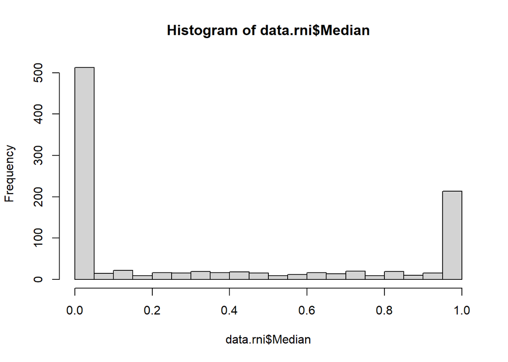

```r
hist(data.rni$Median, breaks = 20)
```

## Work on Filtering the Data

Filtering by Median

```r
data.gss.fd = data.gss[data.gss$Median < 1 & data.gss$Median > 0,]
length(data.gss.fd$PgS)
```

```
## [1] 110
```

```r
data.uni.fd = data.uni[data.uni$Median < 1 & data.uni$Median > 0,]
length(data.uni.fd$PgS)
```

```
## [1] 157
```

```r
data.rni.fd = data.rni[data.rni$Median < 1 & data.rni$Median > 0,]
length(data.rni.fd$PgS)
```

```
## [1] 311
```

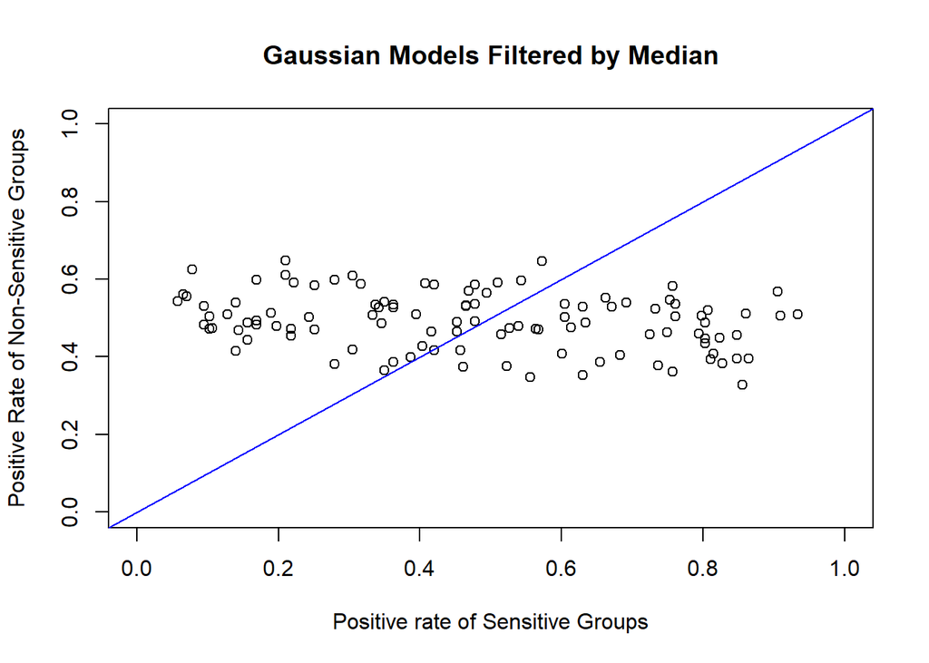

```r
with(data.gss.fd, plot(PgNS~PgS, ylab = "Positive Rate of Non-Sensitive Groups", xlab = "Positive rate of Sensitive Groups", main = "Gaussian Models Filtered by Median", ylim = c(0,1), xlim = c(0,1)))
abline(0, 1, col = "Blue")
```

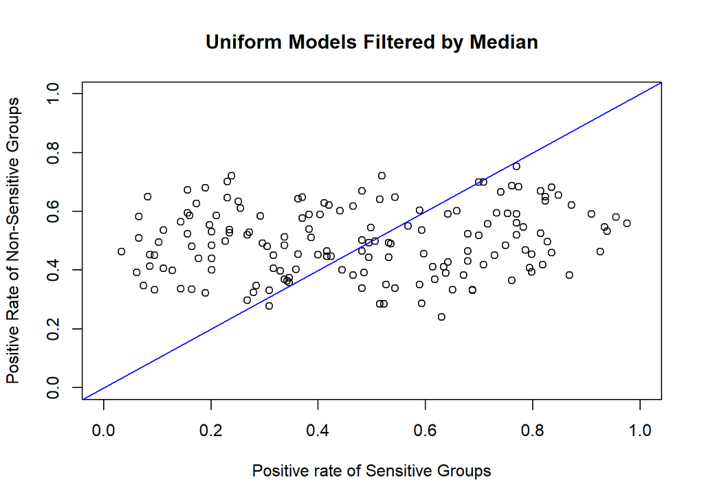

```r
with(data.uni.fd, plot(PgNS~PgS, ylab = "Positive Rate of Non-Sensitive Groups", xlab = "Positive rate of Sensitive Groups", main = "Uniform Models Filtered by Median", ylim = c(0,1), xlim = c(0,1)))
abline(0, 1, col = "Blue")
```

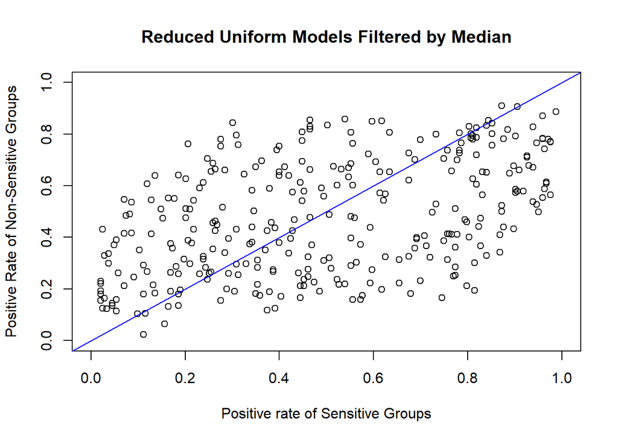

```r
with(data.rni.fd, plot(PgNS~PgS, ylab = "Positive Rate of Non-Sensitive Groups", xlab = "Positive rate of Sensitive Groups", main = "Reduced Uniform Models Filtered by Median", ylim = c(0,1), xlim = c(0,1)))
abline(0, 1, col = "Blue")
```

Filtering by Mean

```r
data.gss.fn = data.gss[data.gss$MeanScore < 0.95 & data.gss$MeanScore > 0.05,]
length(data.gss.fn$PgS)
```

```
## [1] 566
```

```r
data.uni.fn = data.uni[data.uni$MeanScore < 0.95 & data.uni$MeanScore > 0.05,]
length(data.uni.fn$PgS)
```

```
## [1] 569
```

```r
data.rni.fn = data.rni[data.rni$MeanScore < 0.95 & data.rni$MeanScore > 0.05,]
length(data.rni.fn$PgS)
```

```
## [1] 562
```

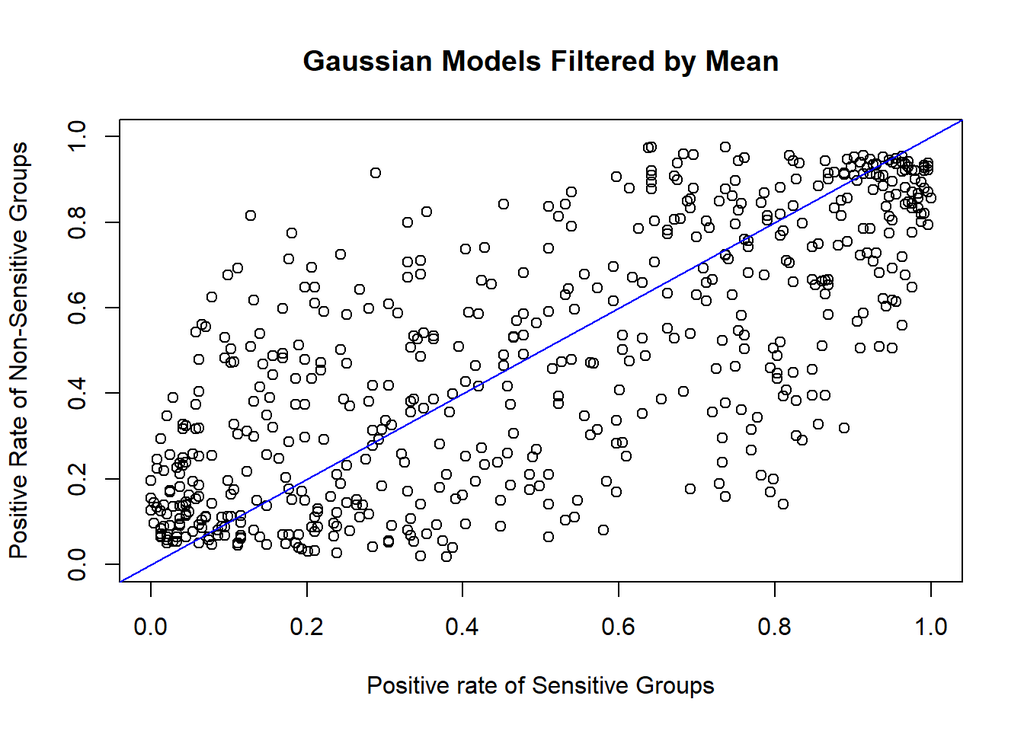

```r
with(data.gss.fn, plot(PgNS~PgS, ylab = "Positive Rate of Non-Sensitive Groups", xlab = "Positive rate of Sensitive Groups", main = "Gaussian Models Filtered by Mean", ylim = c(0,1), xlim = c(0,1)))
abline(0, 1, col = "Blue")
```

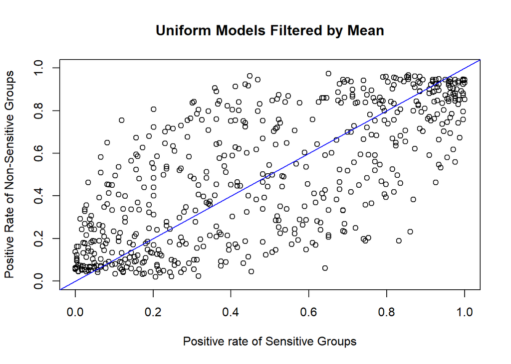

```r
with(data.uni.fn, plot(PgNS~PgS, ylab = "Positive Rate of Non-Sensitive Groups", xlab = "Positive rate of Sensitive Groups", main = "Uniform Models Filtered by Mean", ylim = c(0,1), xlim = c(0,1)))
abline(0, 1, col = "Blue")
```

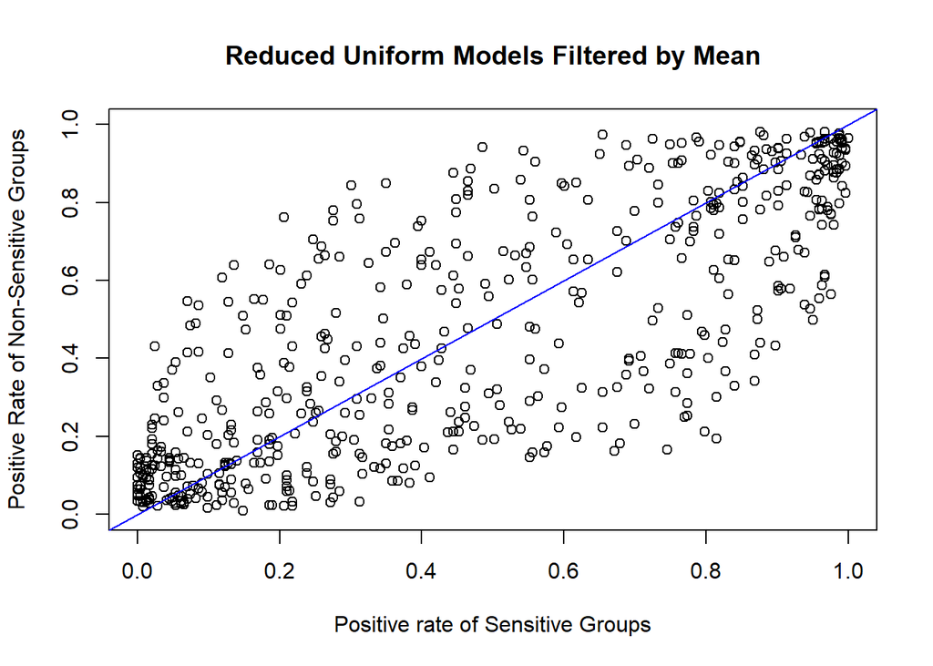

```r
with(data.rni.fn, plot(PgNS~PgS, ylab = "Positive Rate of Non-Sensitive Groups", xlab = "Positive rate of Sensitive Groups", main = "Reduced Uniform Models Filtered by Mean", ylim = c(0,1), xlim = c(0,1)))
abline(0, 1, col = "Blue")
```

## More No Context Graphs

Boxplots of Parity, grouped by filtering

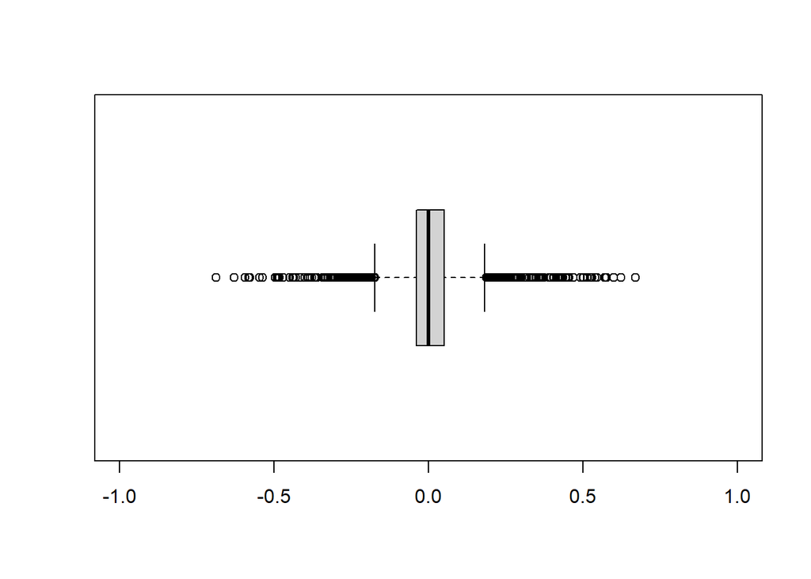

```r
boxplot(data.gss$Parity, horizontal=TRUE, ylim = c(-1,1))
```

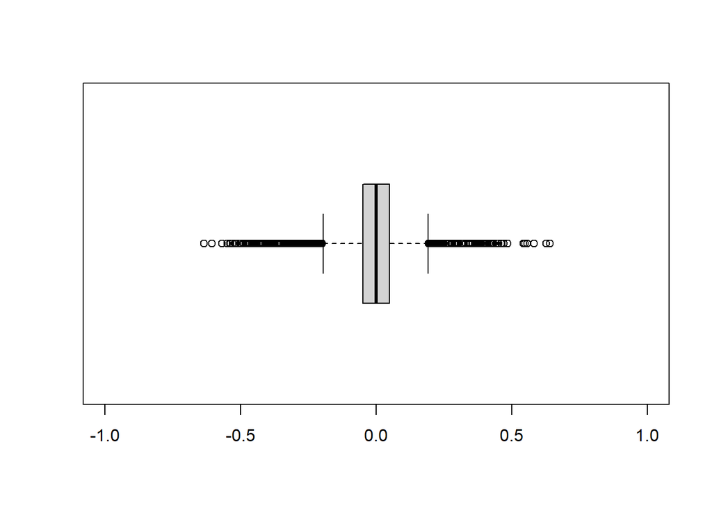

```r
boxplot(data.uni$Parity, horizontal=TRUE, ylim = c(-1,1))
```

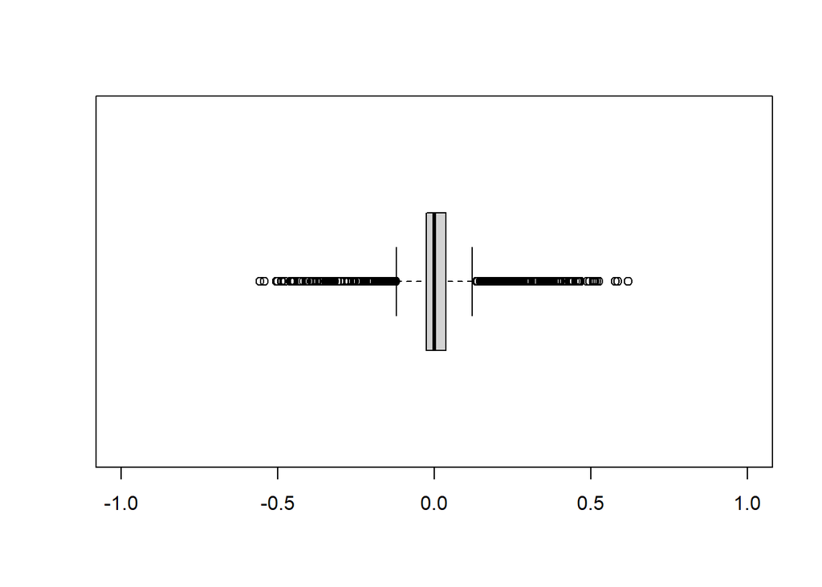

```r
boxplot(data.rni$Parity, horizontal=TRUE, ylim = c(-1,1))
```

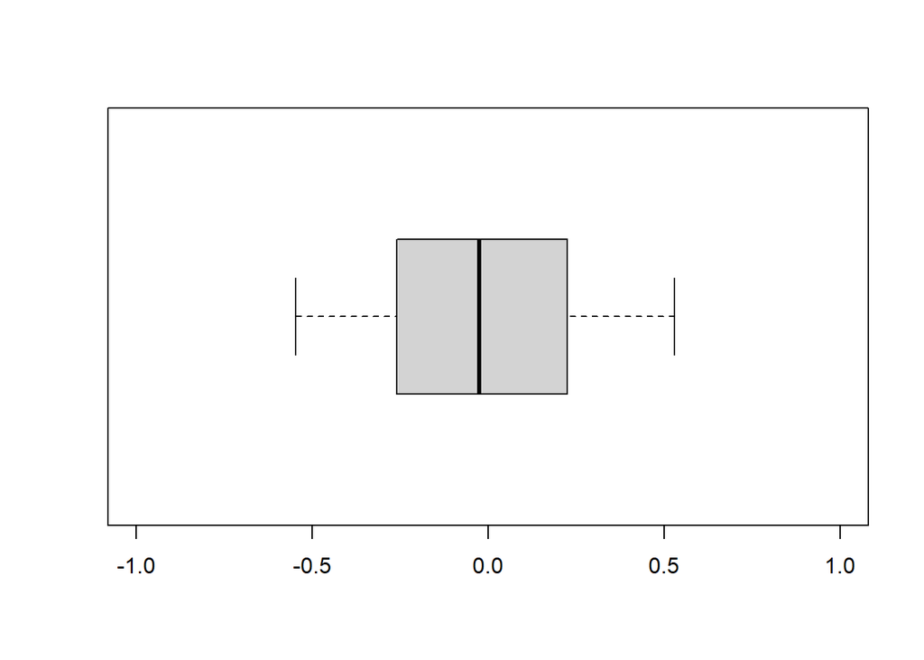

```r
boxplot(data.gss.fd$Parity, horizontal = TRUE, ylim = c(-1,1))
```

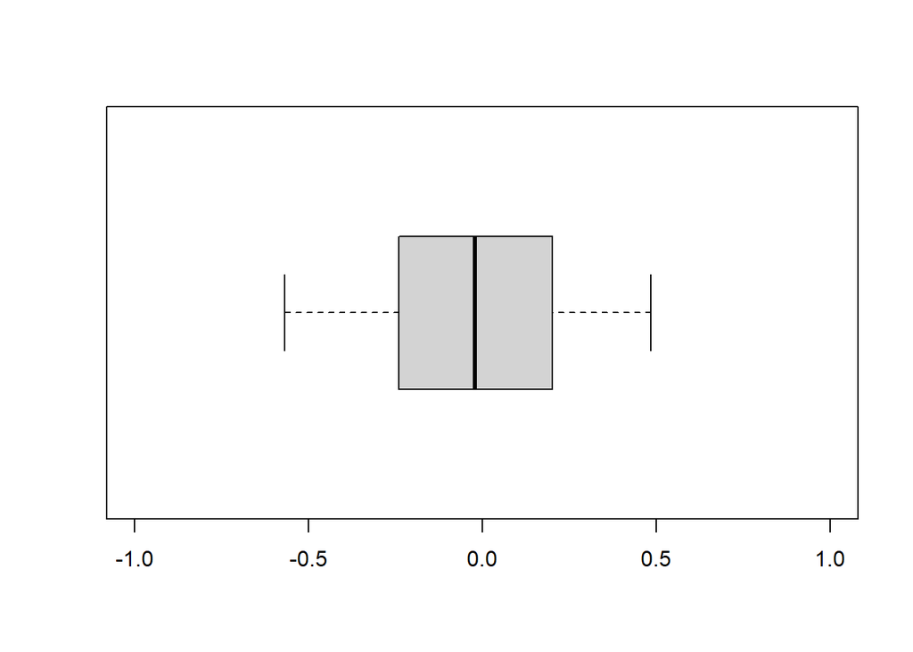

```r
boxplot(data.uni.fd$Parity, horizontal=TRUE, ylim = c(-1,1))
```

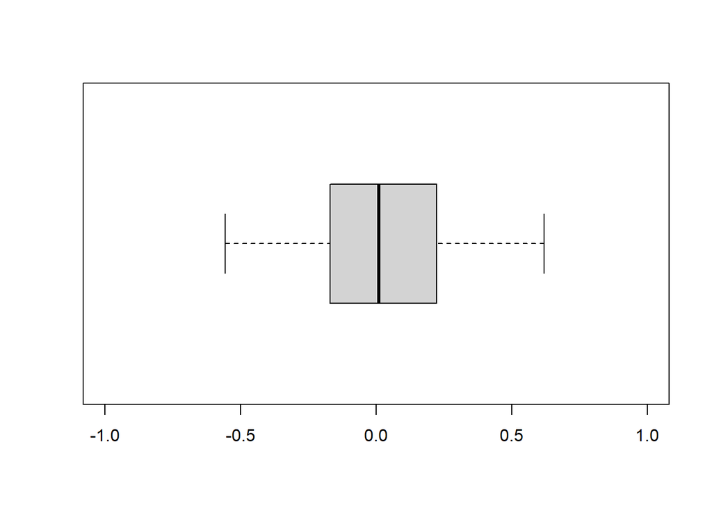

```r
boxplot(data.rni.fd$Parity, horizontal=TRUE, ylim = c(-1,1))
```

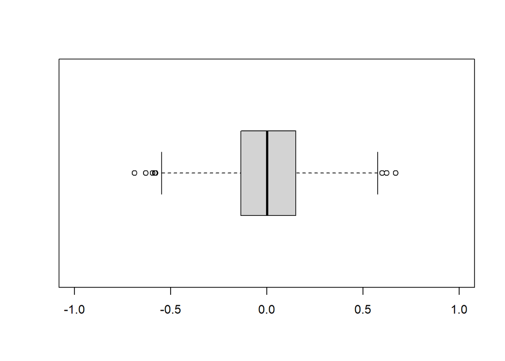

```r
boxplot(data.gss.fn$Parity, horizontal = TRUE, ylim = c(-1,1))
```

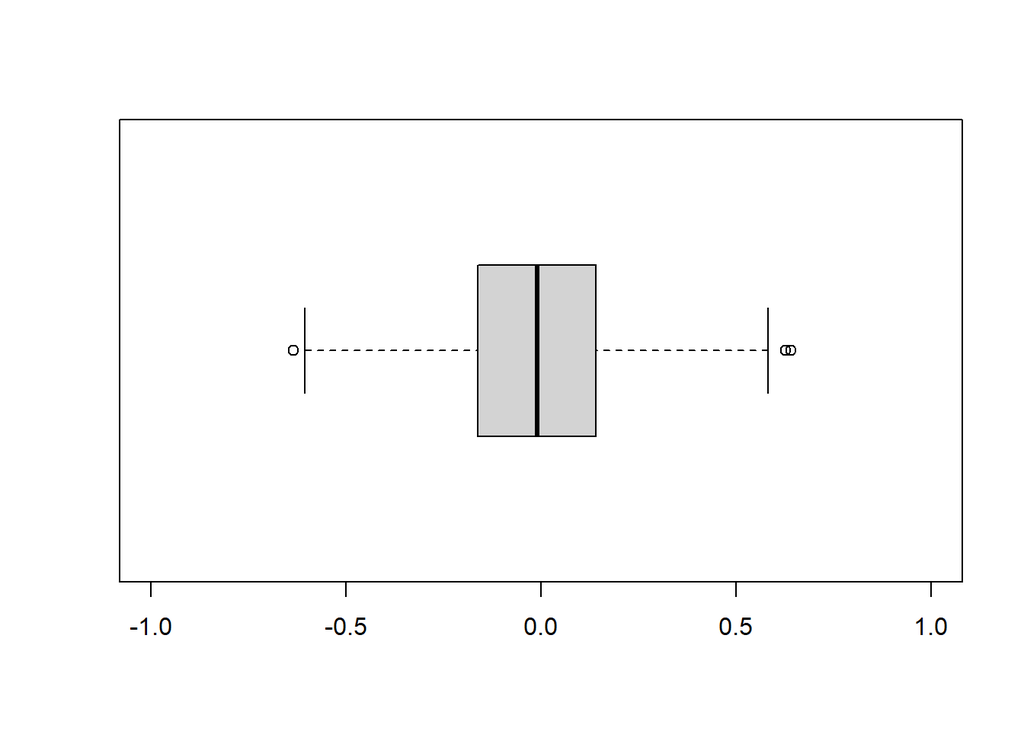

```r
boxplot(data.uni.fn$Parity, horizontal=TRUE, ylim = c(-1,1))
```

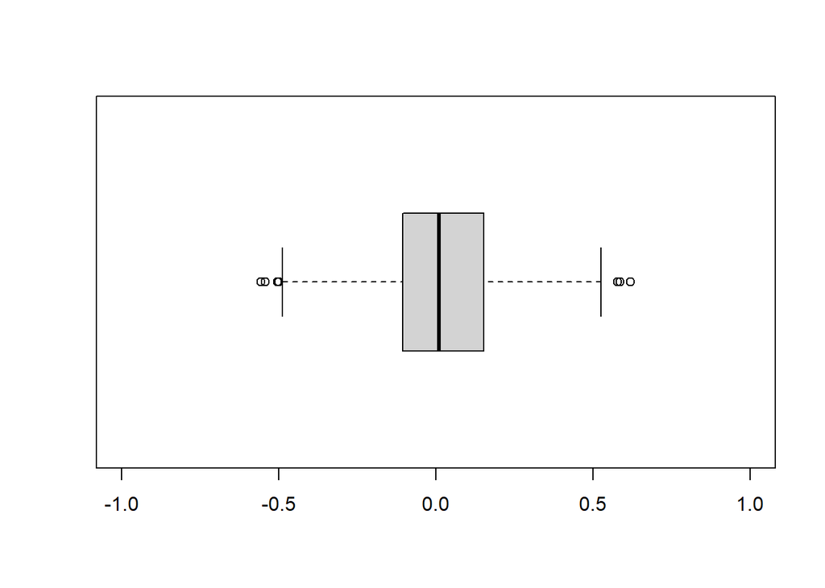

```r
boxplot(data.rni.fn$Parity, horizontal=TRUE, ylim = c(-1,1))
```

Histograms of Parity, grouped by filtering

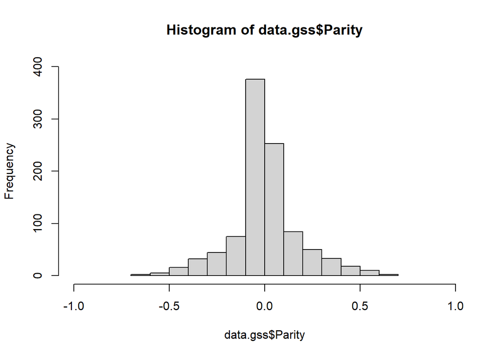

```r
hist(data.gss$Parity, xlim = c(-1,1), ylim = c(0,400))
```

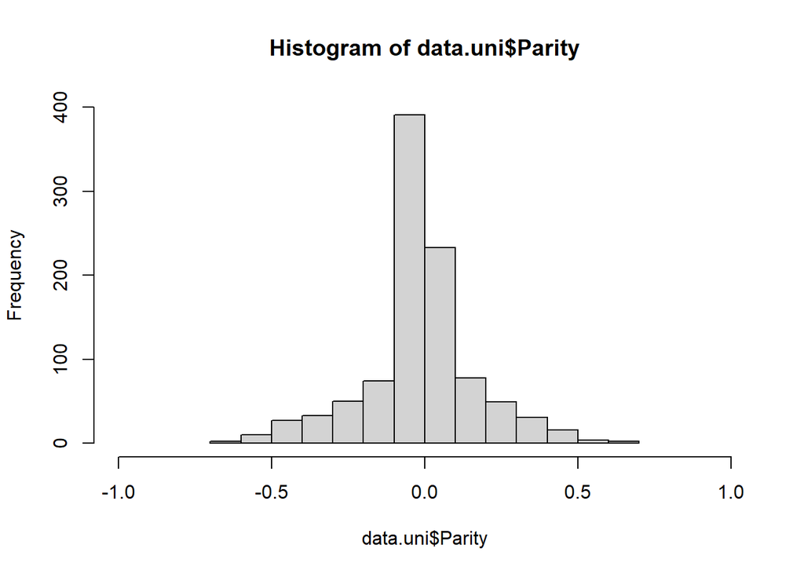

```r
hist(data.uni$Parity, xlim = c(-1,1), ylim = c(0,400))
```

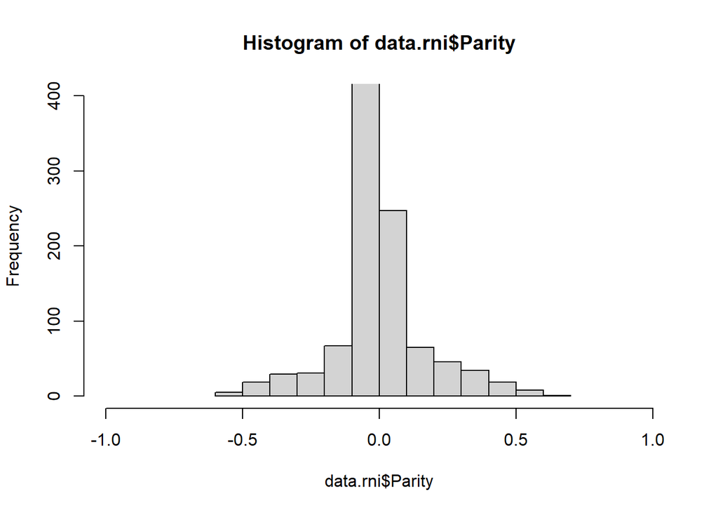

```r
hist(data.rni$Parity, xlim = c(-1,1), ylim = c(0,400))
```

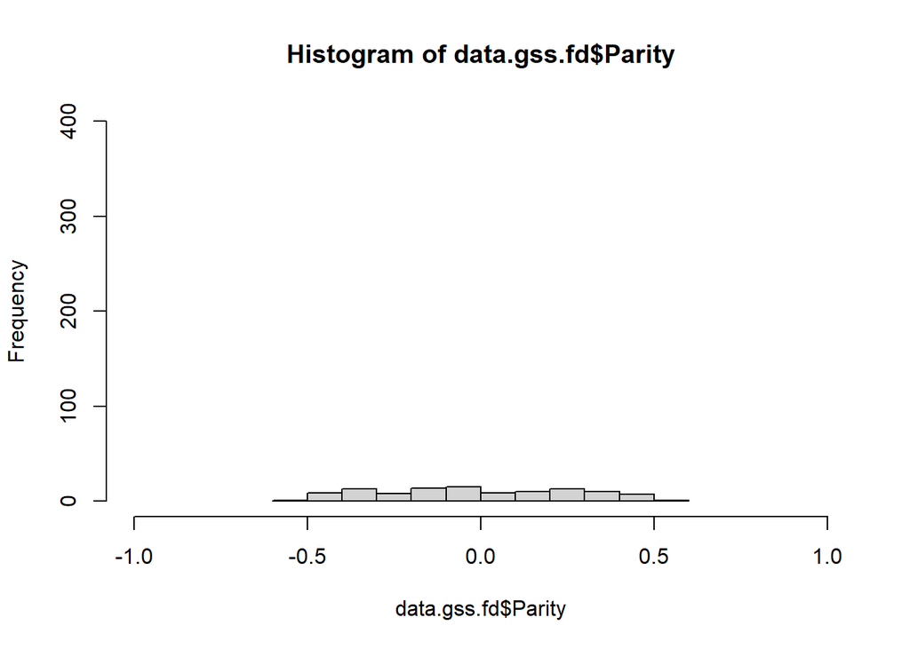

```r
hist(data.gss.fd$Parity, xlim = c(-1,1), ylim = c(0,400))
```

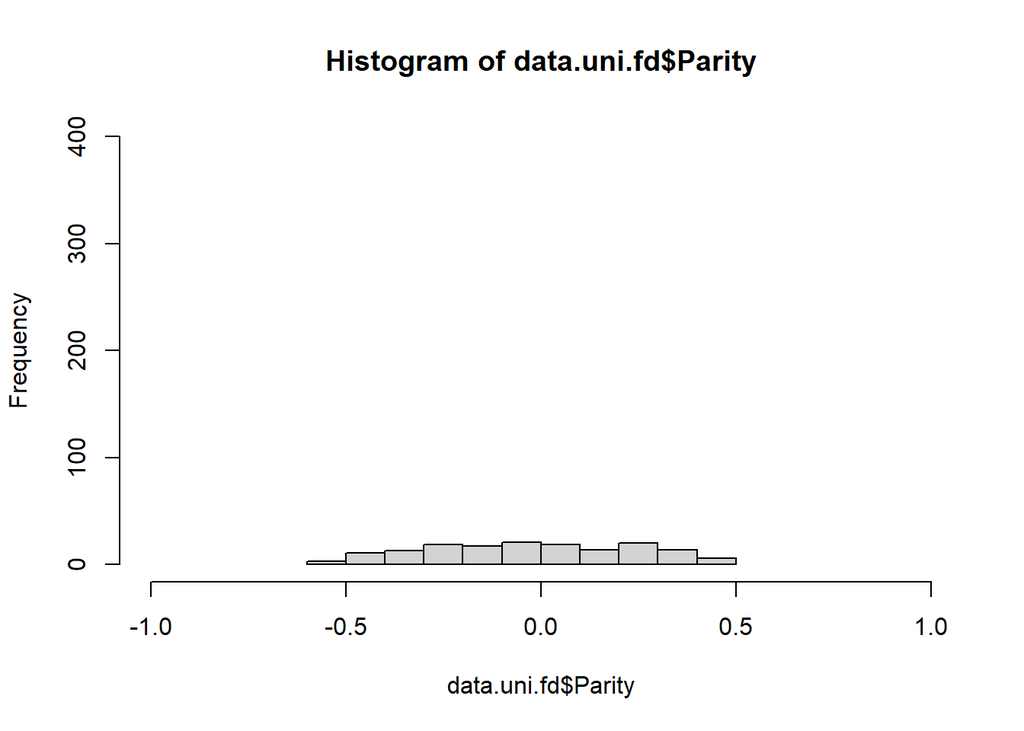

```r
hist(data.uni.fd$Parity, xlim = c(-1,1), ylim = c(0,400))
```

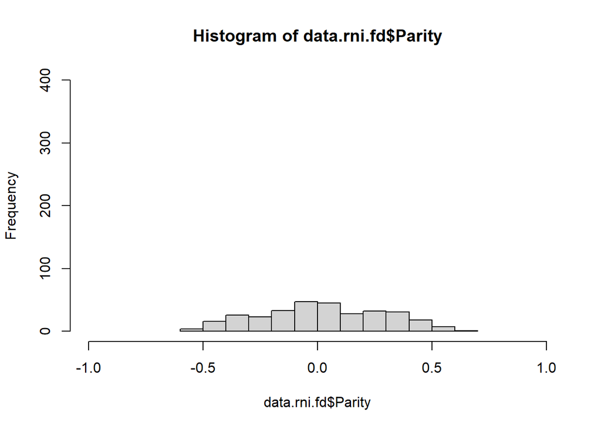

```r
hist(data.rni.fd$Parity, xlim = c(-1,1), ylim = c(0,400))
```

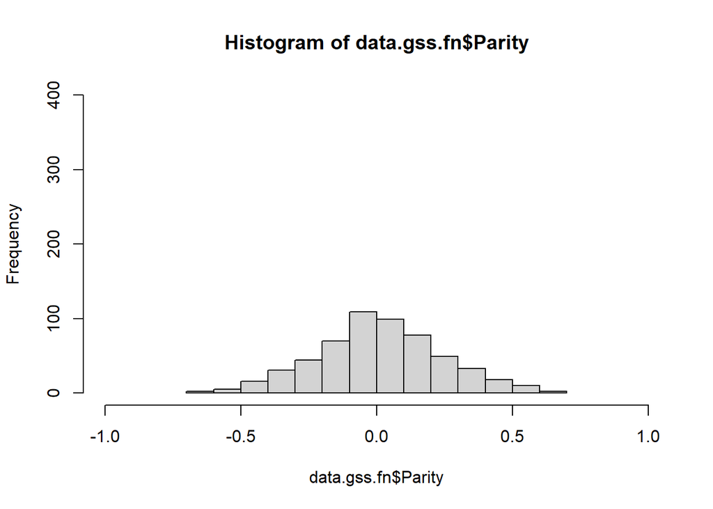

```r
hist(data.gss.fn$Parity, xlim = c(-1,1), ylim = c(0,400))
```

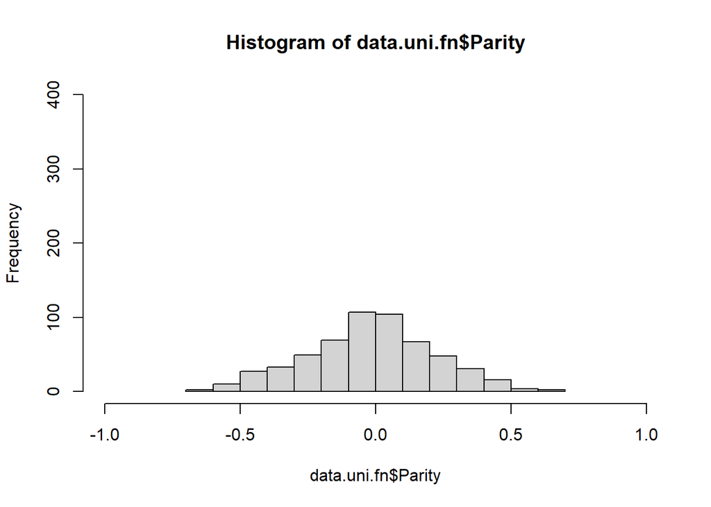

```r
hist(data.uni.fn$Parity, xlim = c(-1,1), ylim = c(0,400))
```

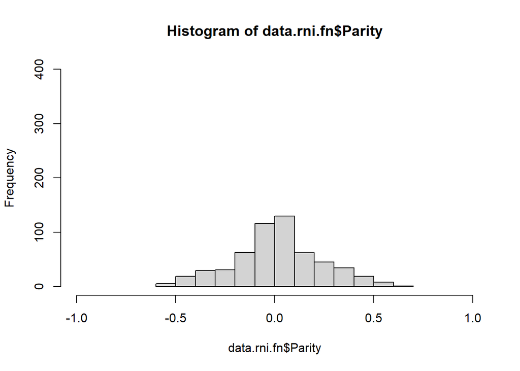

```r
hist(data.rni.fn$Parity, xlim = c(-1,1), ylim = c(0,400))
```